# Notebook

```python
import pandas as pd
pd.options.display.max_rows = 6
%matplotlib inline
```

```python
crimes = pd.read_csv('Crimes_-_2001_to_present.csv', parse_dates=['Date'])
```

## Group By

Given a *key* column, one can partition a table into *groups*:

```python
crimes50_by_community = crimes.head(50).groupby('Community Area')
crimes50_by_community.groups
```

```
{1: [26],
 6: [3, 13],
 8: [28, 38, 45, 49],
 13: [14],
 14: [1, 43],
 19: [30],
 22: [0, 27],
 23: [32],
 24: [31],
 25: [5, 24, 42],
 28: [10, 11, 22, 36],
 29: [33, 40],
 30: [16, 25],
 32: [4],
 33: [37],
 37: [48],
 41: [2],
 43: [7, 8, 20],
 49: [29],
 56: [23],
 58: [21, 46],
 61: [47],
 63: [9],
 67: [15, 19],
 69: [17],
 70: [41, 44],
 71: [6, 34],
 75: [12],
 76: [18],
 77: [35, 39]}
```

```python
crimes_by_community = crimes.groupby('Community Area')
```

## Aggregate

We can aggregate a column over the groups using an aggregate function.

- Built-in functions include 'sum' 'mean' 'median' 'mode' 'count' 'std' 'nunique'.
- Can also pass an arbitrary function whose argument is a vector and returns a scalar.

```python
community_crime_count = crimes_by_community['ID'].agg('count')
community_crime_count
```

```
Community Area
1     259
2     263
3     263
     ...
75    118
76    112
77    166
Name: ID, dtype: int64
```

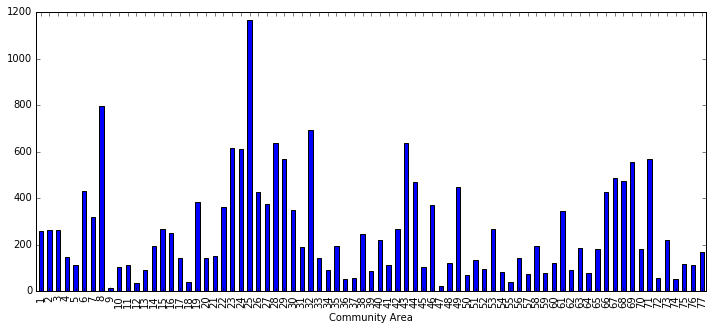

```python
community_crime_count.plot(kind='bar', figsize=(12,5))
```

## Daily Timeseries

```python
def to_day(timestamp):
    return timestamp.replace(minute=0,hour=0, second=0)

crimes['Day'] = crimes['Date'].apply(to_day)
```

```python
crimes_by_day = crimes.groupby('Day')
```

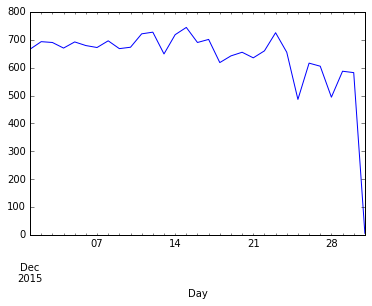

```python
crimes_by_day['ID'].agg('count').plot()
```

What about a time series for a single community area?

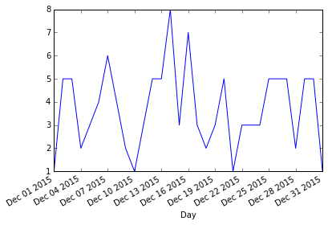

```python
crimes[crimes['Community Area'] == 41].groupby('Day')['ID'].agg('count').plot()
```

## Multiple Group By

To get a series for each community area we could just loop over them. But there is a better way.

Group by can take *multiple* keys, in this case community area and day. The result has a (row) *multi-index*.

```python
crimes_by_community_day = crimes.groupby(['Community Area', 'Day'])
crimes_by_community_day_count = crimes_by_community_day['ID'].agg('count')
```

```python
crimes_by_community_day_count
```

```
Community Area  Day
1               2015-12-01    14
                2015-12-02    12
                2015-12-03     6
                              ..
77              2015-12-28     8
                2015-12-29     4
                2015-12-30     5
Name: ID, dtype: int64
```

Similarly for arrests, then we can take their quotient:

```python
crimes_by_community_day_arrests = crimes_by_community_day['Arrest'].agg('sum')
```

```python
community_day_arrest_prop = crimes_by_community_day_arrests / crimes_by_community_day_count
community_day_arrest_prop
```

```
Community Area  Day
1               2015-12-01    0.214286
                2015-12-02    0.166667
                2015-12-03    0.166667
                                ...
77              2015-12-28    0.250000
                2015-12-29    0.500000
                2015-12-30    0.000000
dtype: float64
```

## How can we plot multiple of these time series together? Unstacking

```python
community_day_arrest_prop.unstack('Community Area')
```

| Community Area Day | 1 | 2 | 3 | 4 | 5 | 6 | 7 | 8 | 9 | 10 | ... | 68 | 69 | 70 | 71 | 72 | 73 | 74 | 75 | 76 | 77 |
| --- | --- | --- | --- | --- | --- | --- | --- | --- | --- | --- | --- | --- | --- | --- | --- | --- | --- | --- | --- | --- | --- |
| 2015-12-01 | 0.214286 | 0.133333 | 0.100000 | 0.375 | 0.200000 | 0.076923 | 0.000000 | 0.000000 | NaN | 0.000000 | ... | 0.333333 | 0.318182 | 0.111111 | 0.285714 | 0.0 | 0.000000 | 0.000000 | 0.000000 | 0.400000 | 0.0 |
| 2015-12-02 | 0.166667 | 0.000000 | 0.100000 | 0.250 | 0.000000 | 0.000000 | 0.000000 | 0.173913 | 0 | 0.000000 | ... | 0.173913 | 0.307692 | 0.000000 | 0.347826 | 0.0 | 0.500000 | 0.500000 | 0.166667 | 0.166667 | 0.0 |
| 2015-12-03 | 0.166667 | 0.181818 | 0.333333 | 0.000 | 0.000000 | 0.166667 | 0.000000 | 0.031250 | 0 | 0.000000 | ... | 0.250000 | 0.210526 | 0.142857 | 0.125000 | 0.0 | 0.285714 | 0.000000 | 0.000000 | 0.000000 | 0.0 |
| ... | ... | ... | ... | ... | ... | ... | ... | ... | ... | ... | ... | ... | ... | ... | ... | ... | ... | ... | ... | ... | ... |
| 2015-12-29 | 0.000000 | 0.285714 | 0.083333 | 0.000 | 0.333333 | 0.125000 | 0.000000 | 0.217391 | NaN | 0.000000 | ... | 0.277778 | 0.200000 | 0.142857 | 0.277778 | NaN | 0.125000 | 0.333333 | 0.000000 | 0.000000 | 0.5 |
| 2015-12-30 | 0.000000 | 0.250000 | 0.428571 | 0.000 | 0.000000 | 0.272727 | 0.133333 | 0.222222 | NaN | 0.333333 | ... | 0.181818 | 0.260870 | 0.000000 | 0.142857 | 0.5 | 0.125000 | 0.000000 | 0.000000 | 0.250000 | 0.0 |
| 2015-12-31 | NaN | NaN | NaN | NaN | NaN | 0.000000 | NaN | NaN | NaN | NaN | ... | NaN | NaN | NaN | NaN | NaN | NaN | NaN | NaN | NaN | NaN |

31 rows × 77 columns

There are missing values after reshaping.  
That means there were no crimes in that area on that day so `fillna(0)`

```python
community_arrest_timeseries = community_day_arrest_prop.unstack('Community Area')
community_arrest_timeseries.fillna(0, inplace=True)
community_arrest_timeseries
```

| Community Area Day | 1 | 2 | 3 | 4 | 5 | 6 | 7 | 8 | 9 | 10 | ... | 68 | 69 | 70 | 71 | 72 | 73 | 74 | 75 | 76 | 77 |
| --- | --- | --- | --- | --- | --- | --- | --- | --- | --- | --- | --- | --- | --- | --- | --- | --- | --- | --- | --- | --- | --- |
| 2015-12-01 | 0.214286 | 0.133333 | 0.100000 | 0.375 | 0.200000 | 0.076923 | 0.000000 | 0.000000 | 0 | 0.000000 | ... | 0.333333 | 0.318182 | 0.111111 | 0.285714 | 0.0 | 0.000000 | 0.000000 | 0.000000 | 0.400000 | 0.0 |
| 2015-12-02 | 0.166667 | 0.000000 | 0.100000 | 0.250 | 0.000000 | 0.000000 | 0.000000 | 0.173913 | 0 | 0.000000 | ... | 0.173913 | 0.307692 | 0.000000 | 0.347826 | 0.0 | 0.500000 | 0.500000 | 0.166667 | 0.166667 | 0.0 |
| 2015-12-03 | 0.166667 | 0.181818 | 0.333333 | 0.000 | 0.000000 | 0.166667 | 0.000000 | 0.031250 | 0 | 0.000000 | ... | 0.250000 | 0.210526 | 0.142857 | 0.125000 | 0.0 | 0.285714 | 0.000000 | 0.000000 | 0.000000 | 0.0 |
| ... | ... | ... | ... | ... | ... | ... | ... | ... | ... | ... | ... | ... | ... | ... | ... | ... | ... | ... | ... | ... | ... |
| 2015-12-29 | 0.000000 | 0.285714 | 0.083333 | 0.000 | 0.333333 | 0.125000 | 0.000000 | 0.217391 | 0 | 0.000000 | ... | 0.277778 | 0.200000 | 0.142857 | 0.277778 | 0.0 | 0.125000 | 0.333333 | 0.000000 | 0.000000 | 0.5 |
| 2015-12-30 | 0.000000 | 0.250000 | 0.428571 | 0.000 | 0.000000 | 0.272727 | 0.133333 | 0.222222 | 0 | 0.333333 | ... | 0.181818 | 0.260870 | 0.000000 | 0.142857 | 0.5 | 0.125000 | 0.000000 | 0.000000 | 0.250000 | 0.0 |
| 2015-12-31 | 0.000000 | 0.000000 | 0.000000 | 0.000 | 0.000000 | 0.000000 | 0.000000 | 0.000000 | 0 | 0.000000 | ... | 0.000000 | 0.000000 | 0.000000 | 0.000000 | 0.0 | 0.000000 | 0.000000 | 0.000000 | 0.000000 | 0.0 |

31 rows × 77 columns

Now we can plot multiple community area timeseries:

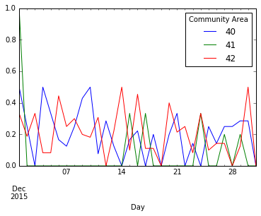

```python
community_arrest_timeseries[[40,41,42]].plot()
```

## Another dataset

Let's look at Chicago's affordable housing dataset

```python
housing = pd.read_csv('Affordable_Rental_Housing_Developments.csv')
```

```python
housing
```

|  | Community Area Name | Community Area Number | Property Type | Property Name | Address | Zip Code | Phone Number | Management Company | Units | X Coordinate | Y Coordinate | Latitude | Longitude | Location |
| --- | --- | --- | --- | --- | --- | --- | --- | --- | --- | --- | --- | --- | --- | --- |
| 0 | Albany Park | 14 | Senior | Mayfair Commons | 4444 W. Lawrence Ave. | 60630 | 773-205-7862 | Metroplex, Inc. | 97 | 1145674.753818 | 1931569.979045 | 41.968224 | -87.739747 | 4444 W. Lawrence Ave.\n(41.9682242321, -87.739... |
| 1 | Albany Park | 14 | Senior | Senior Suites of Ravenswood Manor | 2800 W. Montrose Ave. | 60618 | 773-509-9333 | Senior Lifestyle Corp. | 80 | 1156898.513945 | 1929148.460973 | 41.961359 | -87.698544 | 2800 W. Montrose Ave.\n(41.9613586525, -87.698... |
| 2 | Albany Park | 14 | Senior | Darul Amaan Senior Living | 4814-58 N. Kedzie Ave. | 60625 | 773-463-3004 | East Lake Management & Development Corp. | 56 | NaN | NaN | NaN | NaN | NaN |
| ... | ... | ... | ... | ... | ... | ... | ... | ... | ... | ... | ... | ... | ... | ... |
| 261 | Woodlawn | 42 | Multifamily | The Grant at Woodlawn Pk Phase I | 6227-29 S. Cottage Grove Ave. | 60637 | 312-283-0030 | Preservation Housing Management LLC | 67 | 1186722.404223 | 1863775.146697 | 41.781408 | -87.605807 | 6227-29 S. Cottage Grove Ave.\n(41.7814080037,... |
| 262 | Woodlawn | 42 | Multifamily | The Grant at Woodlawn Pk Phase II | 6129 S. Cottage Grove Ave. | 60637 | 312-283-0030 | Preservation Housing Management LLC | 33 | 1186094.258818 | 1864209.572438 | 41.782505 | -87.590962 | 6129 S. Cottage Grove Ave.\n(41.7825052194, -8... |
| 263 | NaN | NaN | NaN | NaN | NaN | NaN | NaN | NaN | NaN | NaN | 1864312.842731 | 41.782803 | -87.593261 | (41.7828034603, -87.5932613147) |

264 rows × 14 columns

## Join

What if we want to know the crime rate in the community for each housing development?  
We can find this using what's called a *join* or *merge*.  
First let's turn the community_crime_count Series into a DataFrame:

```python
community_area_crime = pd.DataFrame({'Crime Count': community_crime_count})
community_area_crime
```

| Community Area | Crime Count |
| --- | --- |
| 1 | 259 |
| 2 | 263 |
| 3 | 263 |
| ... | ... |
| 75 | 118 |
| 76 | 112 |
| 77 | 166 |

77 rows × 1 columns

```python
housing_crime = housing.merge(community_area_crime,
                              left_on='Community Area Number', right_index=True)
housing_crime
```

|  | Community Area Name | Community Area Number | Property Type | Property Name | Address | Zip Code | Phone Number | Management Company | Units | X Coordinate | Y Coordinate | Latitude | Longitude | Location | Crime Count |
| --- | --- | --- | --- | --- | --- | --- | --- | --- | --- | --- | --- | --- | --- | --- | --- |
| 0 | Albany Park | 14 | Senior | Mayfair Commons | 4444 W. Lawrence Ave. | 60630 | 773-205-7862 | Metroplex, Inc. | 97 | 1145674.753818 | 1931569.979045 | 41.968224 | -87.739747 | 4444 W. Lawrence Ave.\n(41.9682242321, -87.739... | 195 |
| 1 | Albany Park | 14 | Senior | Senior Suites of Ravenswood Manor | 2800 W. Montrose Ave. | 60618 | 773-509-9333 | Senior Lifestyle Corp. | 80 | 1156898.513945 | 1929148.460973 | 41.961359 | -87.698544 | 2800 W. Montrose Ave.\n(41.9613586525, -87.698... | 195 |
| 2 | Albany Park | 14 | Senior | Darul Amaan Senior Living | 4814-58 N. Kedzie Ave. | 60625 | 773-463-3004 | East Lake Management & Development Corp. | 56 | NaN | NaN | NaN | NaN | NaN | 195 |
| ... | ... | ... | ... | ... | ... | ... | ... | ... | ... | ... | ... | ... | ... | ... | ... |
| 260 | Woodlawn | 42 | Senior | Butler Apartments | 6146 S. Kenwood Ave. | 60637 | 773-955-9290 | Woodlawn Comm. Dev. Corp. | 17 | 1182676.846895 | 1862140.114893 | 41.776909 | -87.603954 | 6146 S. Kenwood Ave.\n(41.7769092523, -87.6039... | 265 |
| 261 | Woodlawn | 42 | Multifamily | The Grant at Woodlawn Pk Phase I | 6227-29 S. Cottage Grove Ave. | 60637 | 312-283-0030 | Preservation Housing Management LLC | 67 | 1186722.404223 | 1863775.146697 | 41.781408 | -87.605807 | 6227-29 S. Cottage Grove Ave.\n(41.7814080037,... | 265 |
| 262 | Woodlawn | 42 | Multifamily | The Grant at Woodlawn Pk Phase II | 6129 S. Cottage Grove Ave. | 60637 | 312-283-0030 | Preservation Housing Management LLC | 33 | 1186094.258818 | 1864209.572438 | 41.782505 | -87.590962 | 6129 S. Cottage Grove Ave.\n(41.7825052194, -8... | 265 |

260 rows × 15 columns

## Another aggregate

We can pass other functions to aggregate:

```python
community_housing = pd.DataFrame({
    'Affordable Housing Units': housing.groupby('Community Area Number')['Units'].agg('sum')
})
community_housing
```

| Community Area Number | Affordable Housing Units |
| --- | --- |
| 1 | 517 |
| 2 | 307 |
| 3 | 940 |
| ... | ... |
| 71 | 352 |
| 73 | 142 |
| 77 | 504 |

53 rows × 1 columns

```python
housing_crime_aggregate = community_housing.join(community_area_crime)
housing_crime_aggregate.shape
```

```
(53, 2)
```

## Join types

- left
- right
- inner
- outer

In this case we want an `outer` join.

```python
housing_crime_aggregate = community_housing.merge(
        community_area_crime, left_index=True, right_index=True, how='outer')
housing_crime_aggregate.shape
```

```
(77, 2)
```

```python
housing_crime_aggregate
```

|  | Affordable Housing Units | Crime Count |
| --- | --- | --- |
| 1 | 517 | 259 |
| 2 | 307 | 263 |
| 3 | 940 | 263 |
| ... | ... | ... |
| 75 | NaN | 118 |
| 76 | NaN | 112 |
| 77 | 504 | 166 |

77 rows × 2 columns

Rows without a corresponding row in the merge are filled with missing values. In our case those should be zeros, so we can `fillna(0)`.

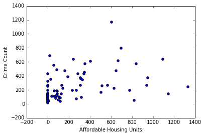

```python
housing_crime_aggregate.fillna(0, inplace=True)
housing_crime_aggregate.plot(kind='scatter', x='Affordable Housing Units', y='Crime Count')
```